# Visualize wGRR plasmid networks

Misha

2026-03-10

```r
library(dplyr)
```

```r
library(readr)
library(stringr)
library(ggplot2)
library(tidyverse)
dist_mat <- read.csv('../output/xanthomonas_wGRR_distance_matrix.csv', row.names = 1)
dist_obj <- as.dist(dist_mat)
```

Visualizing a distance matrix can be done in many ways. Here we explore a dimensionality reduction method (MDS) to visualize the plasmids in 2D space (somewhat similar to PCA):

```r
mds_result <- cmdscale(
  d   = dist_obj,
  k   = 2,
  eig = TRUE,
  add = TRUE
  )
```

Just like a PCA we can find the variance explained by the two axes.

```r
variance_explained <- mds_result$eig / sum(mds_result$eig[mds_result$eig > 0]) * 100
cat(round(variance_explained[1:2], 1), "%")
```

```
## 2.6 1.7 %
```

Oof that’s very low! Keep that in mind while looking at the following scatter plots.

To plot a scatter plot first we get the coordinates from the mds_results

```r
coords <- as.data.frame(mds_result$points)
colnames(coords) <- paste0("MDS", seq_len(2))
coords$plasmid_id <- rownames(dist_mat)
coords <- coords[, c("plasmid_id", paste0("MDS", seq_len(2)))]
```

Plot plasmids in MDS space:

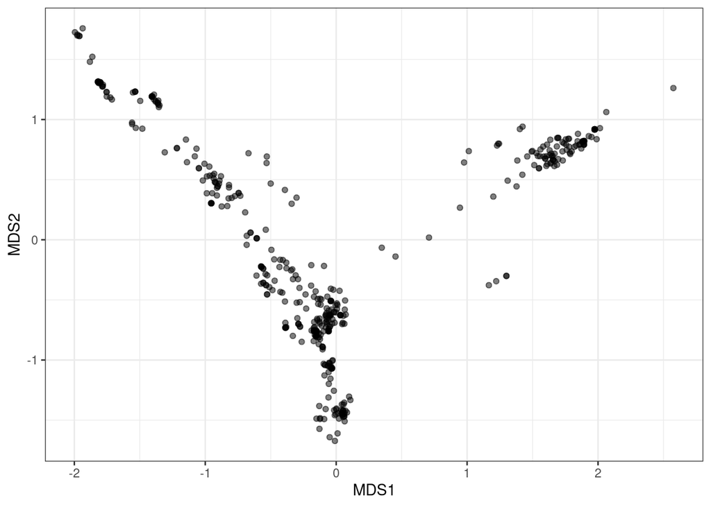

```r
coords %>% ggplot(aes(x = MDS1, y = MDS2)) + geom_point(alpha = 0.5) + theme_bw()
```

```r
metadata <- read_tsv('../data/xanthomonas_metadata.tsv', col_names = c("accession", "species", "taxid", "length"))
metadata <- metadata %>% mutate(species_clean = stringr::word(species, 1, 2))
```

Merge metadata with the plasmid coordinates, plot with color for species:

```r
coords <- merge(coords, metadata, by.x = "plasmid_id", by.y = "accession")
```

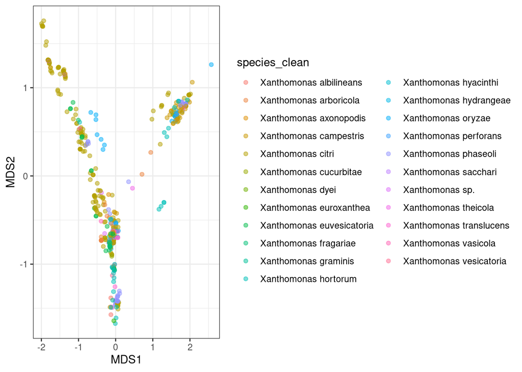

```r
coords %>% ggplot(aes(x = MDS1, y = MDS2, colour = species_clean)) + geom_point(alpha = 0.5) + theme_bw()
```

This is quite cool! It shows different clusters of plasmids, with different colors within clusters. This could indicate plasmid (parts) being shared between different species, however, we need to keep in mind the low percentage of variance explained with the MDA.

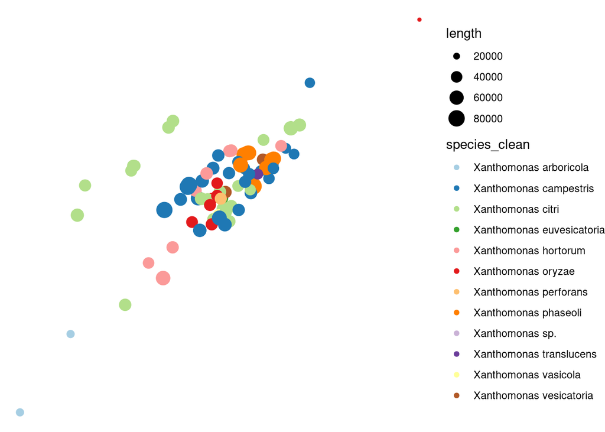

```r
coords %>% filter(MDS1 > 0.5) %>% filter(MDS2 > 0) %>%
  ggplot(aes(x = MDS1, y = MDS2, colour = species_clean, size = length)) +
  geom_point(alpha = 1) +
  scale_colour_brewer(palette = "Paired") +
  theme_void()
```

```
## label_key: species_clean
```

```
## Too many data points, skip labeling
```

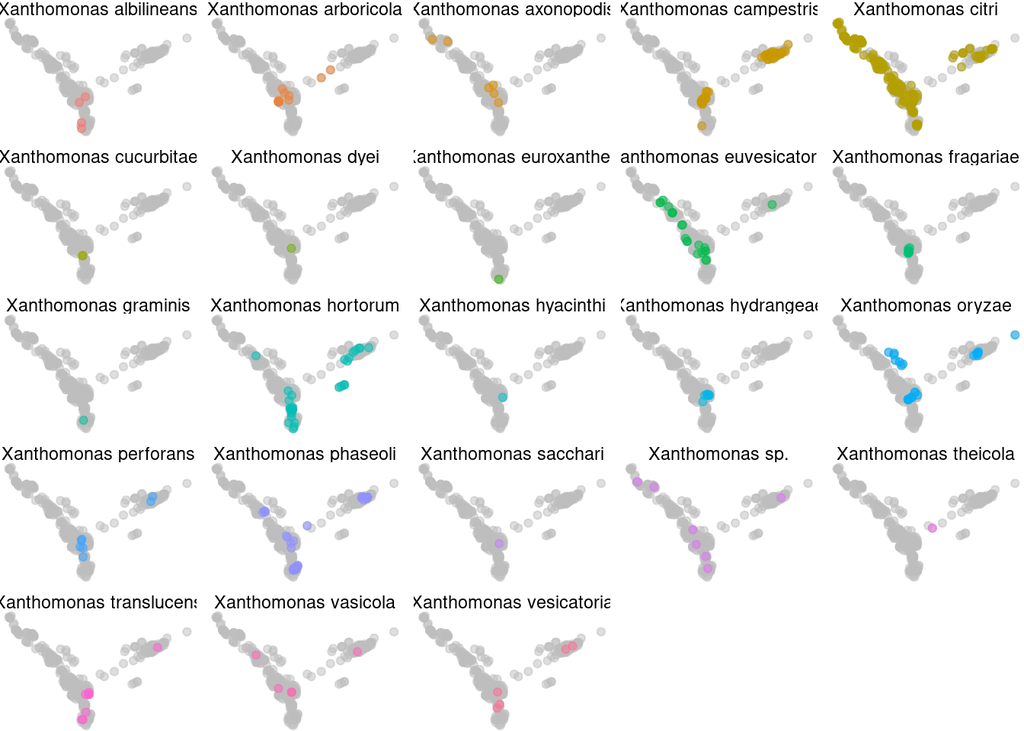

```r
library(gghighlight)

coords %>% ggplot(aes(x = MDS1, y = MDS2, colour = species_clean)) +
  geom_point(alpha = 0.5) +
  gghighlight() +
  facet_wrap(~ species_clean) +
  theme_void()
```

I want to find plasmid pairs of plasmids from different species, and then look for high wGRR values

```r
metadata_minimal <- metadata %>% select(accession, species_clean)

wgrr_pairs <- dist_mat %>%
  as.data.frame() %>%
  rownames_to_column("pA") %>%
  pivot_longer(-1, names_to = "pB", values_to = "distance") %>%
  rename(pA = 1) %>%
  mutate(wGRR = 1 - distance) %>%
  filter(pA != pB) %>%        # exclude self
  filter(pA < pB)         # deduplicate if symmetric


wgrr_pairs_species <- wgrr_pairs %>%
  merge(metadata_minimal, by.x = "pA", by.y = "accession") %>%
  mutate(species_pA = species_clean) %>%
  select(-species_clean) %>%
  merge(metadata_minimal, by.x = "pB", by.y = "accession") %>%
  mutate(species_pB = species_clean) %>%
  select(-species_clean) %>%
  mutate(species_pair = paste(species_pA, species_pB, sep = "-"))
```